# Case Study 2

Justin Cleveland

4/2/2020

# Introduction

Code below was developed to analyze employee data for the purpose of predicting employee turnover. The R code goes through a series of step to import raw data, transform, visualize, and develop prediction based models. The primary goal is to identify factors that lead to employee attrition, however there is additional code developed to predict an employee’s monthly income.

You should identify the top three factors that contribute to turnover (backed up by evidence provided by analysis). There may or may not be a need to create derived attributes/variables/features.

Inaddition The business is also interested in learning about any job role specific trends that may exist in the data set (e.g., “Data Scientists have the highest job satisfaction”). You can also provide any other interesting trends and observations from your analysis.

### Load required R Libraries

```r
library(tidyverse) #Loads core packages including:
#ggplot2, for data visualisation
#dplyr, for data manipulation
#tidyr, for data tidying
#readr, for data import
#purrr, for functional programming
#tibble, for tibbles, a modern re-imagining of data frames
#stringr, for strings
#forcats, for factors
library(GGally) #Used to plot relationship of variables in MLR model
library(ggfortify) #Used to plot MLR residuals and Q-Q plot
library(Metrics) #Used to calculate mse
library(gridExtra) #Used to a more complex graphics to ggplot, grid.arrange function
library(Hmisc) #Used to build correlation matrix table
library(plyr) #Used for data analysis and tidy data
library(caret) #Used to split data into training and testing
library(e1071) #Used for naiveBayes model
library(RCurl) #Used to read data using GetURL fuction
library(corrplot) #Used to build correlation matrix
```

### Import Data

Code below will read data into R from Github

```r
# Read in data for analysis
Data = read.csv(text=getURL("https://raw.githubusercontent.com/JustinCleveland/CaseStudy2DDS/master/CaseStudy2-data.csv"), header = TRUE,   na.strings =c('', 'NA'))
Dataset = Data
Validation_Attrition = read.csv("https://raw.githubusercontent.com/JustinCleveland/CaseStudy2DDS/master/CaseStudy2CompSet No Attrition.csv",header = TRUE,na.strings=c("","NA"))
Validation_Salary = read.csv("https://raw.githubusercontent.com/JustinCleveland/CaseStudy2DDS/master/CaseStudy2CompSet No Salary.csv",header = TRUE,na.strings=c("","NA"))
```

### Transform Data

#### Change factor variables to ordinal variables

```r
#Attrition
Dataset$Att <-            ifelse(grepl("*No*",Dataset$Attrition) , "0", "1")
                          Dataset$Att = as.integer(Dataset$Att)

#Gender
Dataset$Gender <-         ifelse(grepl("*Female*",Dataset$Gender) , "0", "1")
                          Dataset$Gender = as.integer(Dataset$Gender)

#Overtime
Dataset$OverTime <-       ifelse(grepl("*No*",Dataset$OverTime) , "0", "1")
                          Dataset$OverTime = as.integer(Dataset$OverTime)

#BusinessTravel
Dataset$BusinessTravel <- ifelse(grepl("*Non-Travel*", Dataset$BusinessTravel), "0",
                          ifelse(grepl("*Travel_Frequently*", Dataset$BusinessTravel) , "1", "2"))
                          Dataset$BusinessTravel = as.integer(Dataset$BusinessTravel)

#Department
Dataset$Department <-     ifelse(grepl("*Human Resources*", Dataset$Department ), "0",
                          ifelse(grepl("*Research & Development*", Dataset$Department) , "1", "2"))
                          Dataset$Department = as.integer(Dataset$Department )

#MaritalStatus
Dataset$MaritalStatus <-  ifelse(grepl("*Divorced*", Dataset$MaritalStatus), "0",
                          ifelse(grepl("*Married*", Dataset$MaritalStatus) , "1", "2"))
                          Dataset$MaritalStatus = as.integer(Dataset$MaritalStatus)

#EducationField
Dataset$EducationField <- ifelse(grepl("*Human Resources*", Dataset$EducationField), "0",
                          ifelse(grepl("*Life Sciences*", Dataset$EducationField) , "1",
                          ifelse(grepl("*Marketing*", Dataset$EducationField) , "2",
                          ifelse(grepl("*Medical*", Dataset$EducationField) , "3",
                          ifelse(grepl("*Other*", Dataset$EducationField) , "4",
                                 "5")))))
                          Dataset$EducationField = as.integer(Dataset$Department)

#JobRole
Dataset$JobRole <-        ifelse(grepl("*Healthcare Representative*", Dataset$JobRole), "0",
                          ifelse(grepl("*Human Resources*", Dataset$JobRole) , "1",
                          ifelse(grepl("*Laboratory Technician*", Dataset$JobRole) , "2",
                          ifelse(grepl("*Manager*", Dataset$JobRole) , "3",
                          ifelse(grepl("*Manufacturing Director*", Dataset$JobRole) , "4",
                          ifelse(grepl("*Research Director*", Dataset$JobRole) , "5",
                          ifelse(grepl("*Research Scientist*", Dataset$JobRole) , "6",
                          ifelse(grepl("*Sales Executive*", Dataset$JobRole) , "7",
                          "8"))))))))
                          Dataset$JobRole = as.integer(Dataset$JobRole)
```

#### Create Table with variables that have more than one level

Excludes variables: EmployeeCount,EmployeeNumber, Over18, StandardHours

```r
Dataset = Dataset %>% select(ID,Attrition,Att,Age,BusinessTravel,DailyRate,Department,DistanceFromHome,Education,EducationField,EnvironmentSatisfaction,Gender,HourlyRate,JobInvolvement,JobLevel,JobRole,JobSatisfaction,MaritalStatus,MonthlyIncome,MonthlyRate,NumCompaniesWorked,OverTime,PercentSalaryHike,PerformanceRating,RelationshipSatisfaction,StockOptionLevel,TotalWorkingYears,TrainingTimesLastYear,WorkLifeBalance,YearsAtCompany,YearsInCurrentRole,YearsSinceLastPromotion,YearsWithCurrManager)
```

#### Create Test Dataset and Training Dataset using transformed variables

```r
set.seed(4)
Dataset_Index = sample(seq(1:length(Dataset$ID)),round(.7*length(Dataset$ID)))
Dataset_Train = Dataset[Dataset_Index,]
Dataset_Test = Dataset[-Dataset_Index,]
```

### Visualize

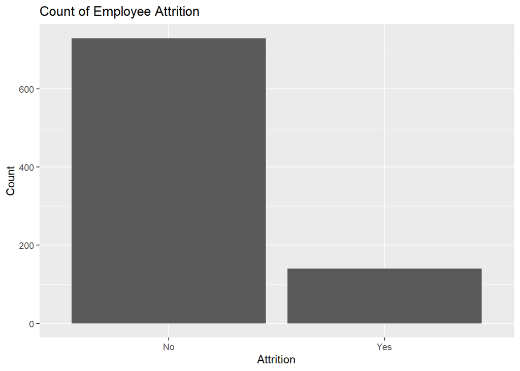

```r
#Bar Plot of Employee Attrition
Data %>%
  ggplot(aes(x=Attrition)) +
  geom_bar() +
  ggtitle("Count of Employee Attrition") + xlab("Attrition") + ylab("Count")
```

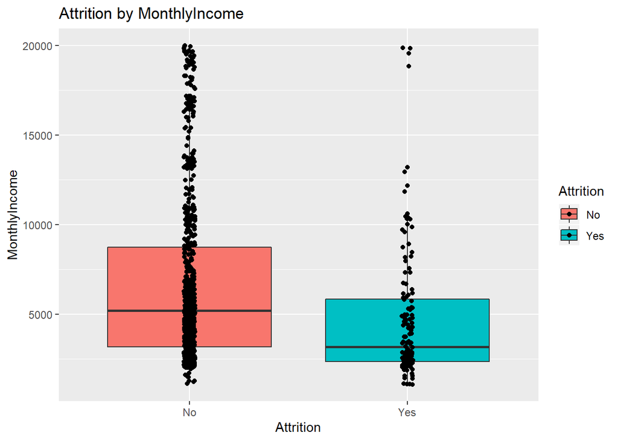

```r
#Group TotalWorking Years and Monthly Income into buckets
Data <- Data %>% mutate(TotWorkingYears=cut(TotalWorkingYears, breaks=c(-Inf, 6, 11, 16,21,31,Inf), labels=c(">5","6-10","11-15","16-20","21-30","<30")))
Data <- Data %>% mutate(MoIncome=cut(MonthlyIncome, breaks=c(-Inf, 5000, 10000, 15000,Inf), labels=c(">$5k","$5K-$10K","$11K-$15k","<$16k")))


Data %>% select(Attrition,MonthlyIncome) %>%
  ggplot(aes(x=Attrition,y=MonthlyIncome,fill=Attrition)) +
  geom_boxplot(outlier.shape=NA) +
  geom_point(aes(fill=Attrition) ,position=position_jitterdodge(jitter.width = .1)) +
  ggtitle("Attrition by MonthlyIncome") + xlab("Attrition") + ylab("MonthlyIncome")
```

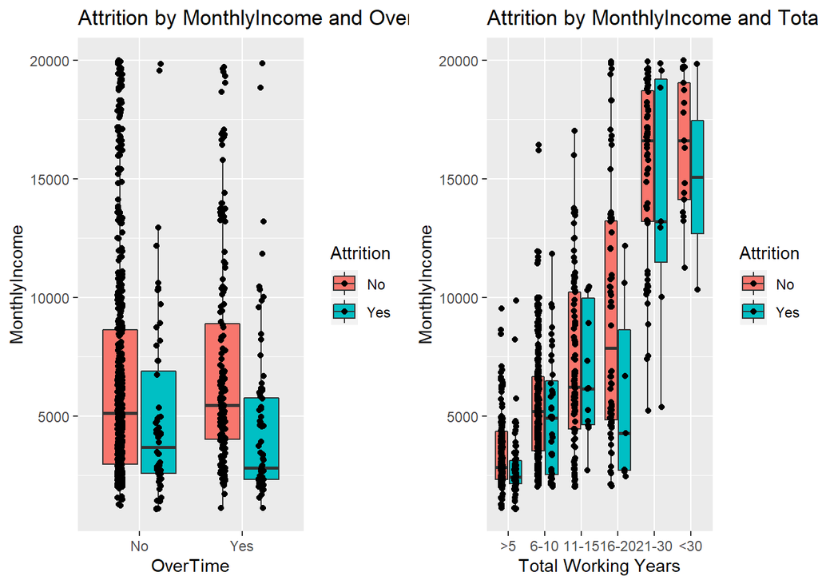

```r
OT = Data %>% select(Attrition,MonthlyIncome,OverTime) %>%
  ggplot(aes(x=OverTime,y=MonthlyIncome,fill=Attrition)) +
  geom_boxplot(outlier.shape=NA) +
  geom_point(aes(fill=Attrition) ,position=position_jitterdodge(jitter.width = .1)) +
  ggtitle("Attrition by MonthlyIncome and OverTime") + xlab("OverTime") + ylab("MonthlyIncome")

TW = Data %>% select(Attrition,MonthlyIncome,TotWorkingYears) %>%
  ggplot(aes(x=TotWorkingYears,y=MonthlyIncome,fill=Attrition)) +
  geom_boxplot(outlier.shape=NA) +
  geom_point(aes(fill=Attrition) ,position=position_jitterdodge(jitter.width = .1)) +
  ggtitle("Attrition by MonthlyIncome and TotalWorkingYears") + xlab("Total Working Years") + ylab("MonthlyIncome")

grid.arrange(OT, TW, ncol=2)
```

#### Identify variables that are correlatted

Custom function to format the correlation matrix to help identify variables correlatted with attrition  
Source for custom function code: https://rstudio-pubs-static.s3.amazonaws.com/240657_5157ff98e8204c358b2118fa69162e18.html

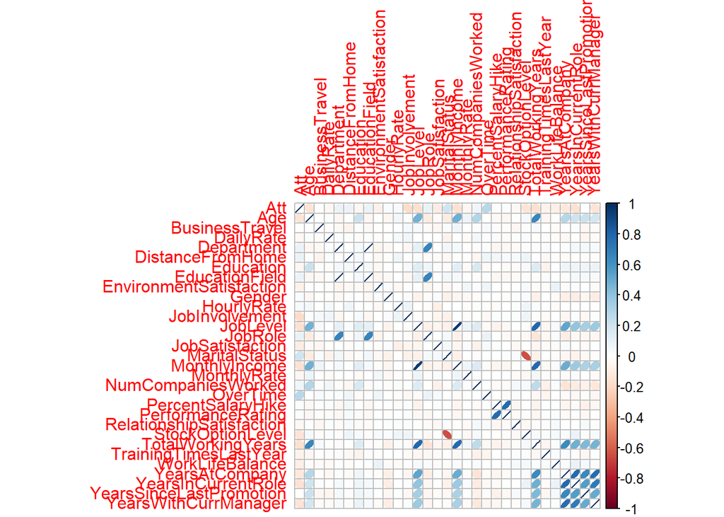

```r
#Custom function to create table of correlated variables
flat_cor_mat <- function(cor_r, cor_p){
  #This function provides a simple formatting of a correlation matrix
  #into a table with 4 columns containing :
    # Column 1 : row names (variable 1 for the correlation test)
    # Column 2 : column names (variable 2 for the correlation test)
    # Column 3 : the correlation coefficients
    # Column 4 : the p-values of the correlations
  cor_r <- rownames_to_column(as.data.frame(cor_r), var = "row")
  cor_r <- gather(cor_r, column, cor, -1)
  cor_p <- rownames_to_column(as.data.frame(cor_p), var = "row")
  cor_p <- gather(cor_p, column, p, -1)
  cor_p_matrix <- left_join(cor_r, cor_p, by = c("row", "column"))
  cor_p_matrix
}

#Create plot of variables
corrplot(cor(Dataset[,c(3:33)]), method = "ellipse")
```

```r
#Create table showing the correlation coeffient with attrition
CorrMatrix <- rcorr(as.matrix(Dataset[,c(3:33)]))
CorrTable = flat_cor_mat(round(CorrMatrix$r,3), round(CorrMatrix$P,3))
CorrTable  %>%
  arrange(p) %>%
  filter(column=='Att') %>%
  select(row,cor,p)
```

```
##                         row    cor     p
## 1                       Age -0.149 0.000
## 2            JobInvolvement -0.188 0.000
## 3                  JobLevel -0.162 0.000
## 4             MaritalStatus  0.197 0.000
## 5             MonthlyIncome -0.155 0.000
## 6                  OverTime  0.272 0.000
## 7          StockOptionLevel -0.149 0.000
## 8         TotalWorkingYears -0.167 0.000
## 9            YearsAtCompany -0.129 0.000
## 10       YearsInCurrentRole -0.156 0.000
## 11     YearsWithCurrManager -0.147 0.000
## 12          JobSatisfaction -0.108 0.001
## 13                  JobRole  0.091 0.008
## 14          WorkLifeBalance -0.090 0.008
```

[output cut: 17 more lines]

### Model

#### Create Naïve Bayes Classification Model to predict employee attrition

```r
# Use original data including factors and numerical data
NB_Dataset = Data %>% select(ID,Attrition,Age,BusinessTravel,DailyRate,Department,DistanceFromHome,Education,EducationField,EnvironmentSatisfaction,Gender,HourlyRate,JobInvolvement,JobLevel,JobRole,JobSatisfaction,MaritalStatus,MonthlyIncome,MonthlyRate,NumCompaniesWorked,OverTime,PercentSalaryHike,PerformanceRating,RelationshipSatisfaction,StockOptionLevel,TotalWorkingYears,TrainingTimesLastYear,WorkLifeBalance,YearsAtCompany,YearsInCurrentRole,YearsSinceLastPromotion,YearsWithCurrManager)
#str(NB_Dataset)

# Create NB Model Test and Training Datasets
NB_Dataset_Index = sample(seq(1:length(NB_Dataset$ID)),round(.7*length(NB_Dataset$ID)))
NB_Dataset_Train = NB_Dataset[NB_Dataset_Index,]
NB_Dataset_Test = NB_Dataset[-NB_Dataset_Index,]

NB_Attrition_Model = naiveBayes(NB_Dataset_Train[,c(3:32)],as.factor(NB_Dataset_Train$Attrition),laplace = 1)
confusionMatrix(table(predict(NB_Attrition_Model,NB_Dataset_Test[,c(3:32)]),as.factor(NB_Dataset_Test$Attrition)))
```

```
## Confusion Matrix and Statistics
##
##
##        No Yes
##   No  185  18
##   Yes  31  27
##
##                Accuracy : 0.8123
##                  95% CI : (0.7595, 0.8578)
##     No Information Rate : 0.8276
##     P-Value [Acc > NIR] : 0.77204
##
##                   Kappa : 0.4096
##
##  Mcnemar's Test P-Value : 0.08648
##
##             Sensitivity : 0.8565
##             Specificity : 0.6000
##          Pos Pred Value : 0.9113
##          Neg Pred Value : 0.4655
##              Prevalence : 0.8276
##          Detection Rate : 0.7088
##    Detection Prevalence : 0.7778
##       Balanced Accuracy : 0.7282
##
##        'Positive' Class : No
##
```